# TS_Ind_Assignment_2_CrossValidation

### **e. Perofrm cross-validation instead of using a single training-test set split.**

To perform cross-validation consider the following:

- The smallest training dataset shall contain at least 50 observations.
- The training datasets shall increase by one observation at a time.

Again, separate in two levels:

1. Performance of the models on average over all forecast horizon.

```r
# Creating training datasets for cross validation
nzarrivals_cv <- nzarrivals %>%
  stretch_tsibble(.init = 50, .step = 1)

# Number of training datasets created
n_tr_datasets <- nzarrivals_cv %>% pull(.id) %>% max()

# Check size of each training dataset
tr_datsets_sizes <-
  nzarrivals_cv %>%
    as_tibble() %>% # Cast to a tibble to be able to do away with time index
    group_by(.id) %>%
    summarize(
      size = n()
    )

fit_cv <- nzarrivals_cv %>%
      model(
        # Model 1: additive decomposition based on STL
        # season_adjust and season_year modelled separately
        decomp = decomposition_model(
                    # Specify decomposition scheme to be used
                    STL(box_cox(Arrivals/1e3, lambda)),
                    # Specify model for the seasonally adjusted component
                    RW(season_adjust ~ drift()),
                    # Specify model for the seasonal component (unnecessary since SNAIVE is default)
                    SNAIVE(season_year)
                    ),

        # Model 2: seasonal naïve component
        seas_naive = SNAIVE(Arrivals)

        )

# Compute the forecasts
fc_cv <- fit_cv %>% forecast(h=8)
```

```r
Let us make some comment about the intermediate results:

We can see that 78 training datasets have been created,
ranging in size from 50 to 127. You can see this by inspecting the variables
`n_tr_datasets` and `tr_datasets_sizes`.

The `mable` variable `fit_cv` has:
  - 78 rows (78 training datasets)
  - Two columns corresponding to the models, because we defined two models.
  - In total we have this fitted 78*2=156 models

The `fable` variable, containing the forecasts has 1248 rows. For each of the
156 fitted models, 8 forecasts are produced. So we get 156*8=1248.

Now let us compute the average performance of each model over all forecast
horizons and training datasets
```

```r
summary_cv <- fc_cv %>%
  accuracy(nzarrivals) %>%
  select(.model, .type, MAE, RMSE, MAPE)
summary_cv
```

```
# A tibble: 2 × 5
  .model     .type    MAE   RMSE  MAPE
  <chr>      <chr>  <dbl>  <dbl> <dbl>
1 decomp     Test  15769. 20528.  7.22
2 seas_naive Test  18586. 25262.  8.62
```

[output not shown]

```r
The decomposition model performs best in every metric for this particular case.
```

2. Performance of the models segregated by forecast horizon.

```r
To segregate by forecast horizon, we need to include an additional column h
that indicates the forecast horizon to which each of the 1248 forecasts in the
object fc_cv corresponds.

For this, we need to use the funciton `row_number()` in combination with group_by
Specifically, we need the cont to reset every time the model or the training
dataset changes. Thus, we will group_by(.id, .model)

The line:

  as_fable(response = "Arrivals", distribution = Arrivals)

ensures that the output is still a `fable`. A `fable` can be used in combination
with the function `accuracy()`, whereas a tsibble cannot.
```

```r
fc_cv <- fc_cv %>%
  group_by(.id, .model) %>%
  mutate(h = row_number()) %>%
  select(h, everything()) %>%
  ungroup() %>%
  as_fable(response = "Arrivals", distribution = Arrivals)

fc_cv
```

```
# A fable: 1,248 x 7 [1Q]
# Key:     .id, Origin, .model [156]
       h   .id Origin .model     Quarter           Arrivals   .mean
   <int> <int> <chr>  <chr>        <qtr>             <dist>   <dbl>
 1     1     1 NZ     decomp     1993 Q3     t(N(13, 0.21)) 148898.
 2     2     1 NZ     decomp     1993 Q4     t(N(12, 0.43)) 135909.
 3     3     1 NZ     decomp     1994 Q1     t(N(11, 0.65))  95310.
 4     4     1 NZ     decomp     1994 Q2     t(N(12, 0.88)) 131794.
 5     5     1 NZ     decomp     1994 Q3      t(N(13, 1.1)) 156520.
 6     6     1 NZ     decomp     1994 Q4      t(N(13, 1.4)) 143182.
 7     7     1 NZ     decomp     1995 Q1      t(N(11, 1.6)) 101265.
 8     8     1 NZ     decomp     1995 Q2      t(N(12, 1.9)) 139038.
 9     1     1 NZ     seas_naive 1993 Q3 N(128550, 3.4e+08) 128550
10     2     1 NZ     seas_naive 1993 Q4 N(136250, 3.4e+08) 136250
# … with 1,238 more rows
```

```r
Now that we have this auxiliar column h, we can use accuracy to compute the
accuracy metrics as follows:
```

```r
summary_cv_h <-
  fc_cv %>%
    accuracy(nzarrivals, by=c("h", ".model"))
summary_cv_h
```

```
# A tibble: 16 × 11
       h .model     .type      ME   RMSE    MAE     MPE  MAPE  MASE RMSSE   ACF1
   <int> <chr>      <chr>   <dbl>  <dbl>  <dbl>   <dbl> <dbl> <dbl> <dbl>  <dbl>
 1     1 decomp     Test    -96.7 13052. 10280. -0.0776  4.79 0.701 0.688 -0.375
 2     1 seas_naive Test   9332.  19265. 14570.  4.31    6.96 0.993 1.01   0.597
 3     2 decomp     Test   -730.  14226. 11265. -0.236   5.19 0.768 0.749  0.297
 4     2 seas_naive Test   9131.  19185. 14438.  4.16    6.84 0.984 1.01   0.614
 5     3 decomp     Test  -1132.  17170. 13352. -0.470   6.32 0.910 0.905  0.292
 6     3 seas_naive Test   9331.  19301. 14552.  4.27    6.87 0.992 1.02   0.614
 7     4 decomp     Test  -1214.  17957. 13534. -0.475   6.44 0.922 0.946  0.626
 8     4 seas_naive Test   9466.  19431. 14740.  4.34    6.95 1.00  1.02   0.607
 9     5 decomp     Test  -1137.  22298. 17659. -0.331   7.98 1.20  1.17   0.535
10     5 seas_naive Test  19112.  30078. 22631.  8.77   10.4  1.54  1.58   0.704
11     6 decomp     Test  -1583.  24295. 19801. -0.461   8.95 1.35  1.28   0.640
12     6 seas_naive Test  19099.  30194. 22667.  8.71   10.4  1.54  1.59   0.705
13     7 decomp     Test  -1864.  25376. 20431. -0.543   9.25 1.39  1.34   0.679
14     7 seas_naive Test  19486.  30389. 22869.  8.92   10.4  1.56  1.60   0.707
15     8 decomp     Test  -1912.  26399. 20801. -0.468   9.27 1.42  1.39   0.735
16     8 seas_naive Test  19700.  30601. 23130.  8.98   10.5  1.58  1.61   0.706
```

```r
Much like before, we can summarize this results in the form of a graph:
```

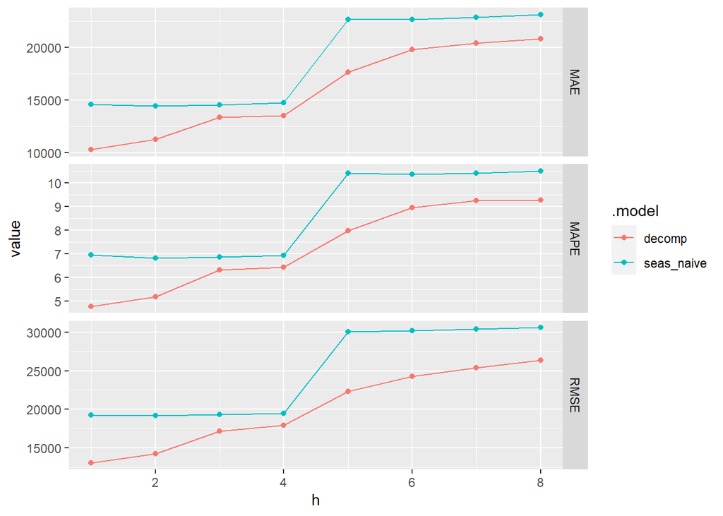

```r
summary_cv_h %>%
  select(h, .model, RMSE, MAE, MAPE) %>%
  pivot_longer(RMSE:MAPE, names_to="metric", values_to="value") %>%
  ggplot(aes(x = h, y = value, color=.model)) +
  geom_line() +
  geom_point() +
  facet_grid(metric ~ ., scales = "free")
```

[output not shown]

3. Do you come to the same conclusions as with a single train-test split? What is the difference between both approaches?

[output not shown]

```r
After having performed multiple train test-splits (specifically 78) and averaged
results over all the training datasets, we now see that, on average, the error
increases with the forecast horizon, as one would expect (uncertainty increases
the longer ahead we forecast).

In addition to this, the behavior of each model seems now to be more consistent.
It appears that now the seas_naive model performs on average worse than the
decomposition model over all forecast horizons

The difference with out previous results is that we have now averaged over
multiple train-test splits instead of over only one.
```